# Impact of Marine Protected Areas on Spiny Lobsters (2012-2018)

Allison Bailey and Becca Reynolds

11/10/2019

#### **Introduction**

The California Spiny Lobster (*Panulirus interruptus*) is a keystone species within nearshore kelp forest ecosystems along the Southern California coast, and a target of both commercial and recreational fisheries. [1] Due to its value as a natural resource, the California Spiny Lobster has received state protection for over a century. [1] On January 1, 2012, California Fish and Game established two Marine Protection Areas (MPA), Naples and Isla Vista, as part of a greater Network of Marine Protected Areas. [2] In spring 2012, the California Department of Fish and Wildlife began developing a Fishery Management Plan (FMP) under the Marine Life Management Act, resulting in the publication of the California Spiny Lobster FMP in spring 2016. [1] The Santa Barbara Coastal Long-Term Ecological Research (SBC LTER) program was established in 2000 to examine the effect of fishing on kelp forest ecosystem dynamics. The SBC LTER program uses interdisciplinary approaches to study the ecology and dynamics of coastal kelp forest communities in nearshore waters along the coast of southern California. [2] From 2012 to 2018, the SBC LTER program collected data on California Spiny Lobster abundance and size in the nearshore waters of the Santa Barbara Channel. The following report will compare California Spiny Lobster size and abundance data from 2012 to 2018 across five SBC LTER study sites, representing MPA sites in dark grey and non-MPA sites in teal.

[figure not shown]

**Figure 1.** California Spiny Lobster (left) and spatial coverage of SBC LTER data collection sites (right). Credit: [Joel Sartore](https://www.joelsartore.com/inv002-00050/) and [SBC LTER EDI Data Portal Site](https://portal.edirepository.org/nis/mapbrowse?scope=knb-lter-sbc&identifier=77&revision=newest)

#### **Results**

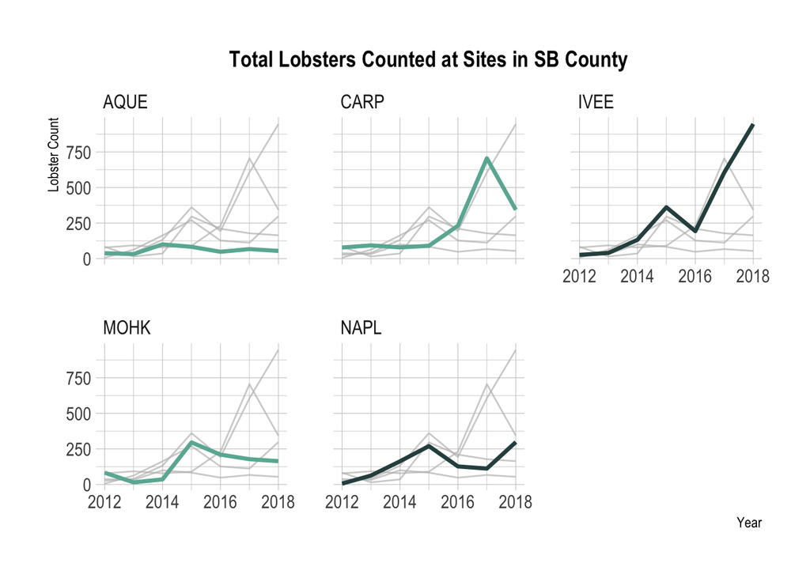

**Figure 2.** Graphs visualize fluctuations in lobster abundance from 2012-2018 across SBC LTER study sites within the Santa Barbara Channel. MPA study sites include Naples (NAPL) and Isla Vista (IVEE). Non-MPA sites include Arroyo Quemado (AQUE), Mohawk (MOHK), and Carpinteria (CARP).

**A. Changes in annual California Spiny Lobster abundance for all Santa Barbara Coastline sites:**

As of December 2009, the IUCN Red List of Threatened Species has deemed the California Spiny Lobster a species of Least Concern, with a stable population trend. [3] The California Spiny Lobster abundance data collected by the SBC LTER program examines a small percentage of the total California Spiny Lobster population across the species’ geographic range. However, general trends in this data provide evidence of stable, and in some cases increasing, populations within the nearshore kelp forests of the Santa Barbara Channel. Despite the fact that declines in abundance are observed in Carpenteria from 2017-2018, and Naples and Isla Vista from 2015-2016, all study sites have experienced some level of overall increase in California Spiny Lobster abundance from 2012 to 2018, with Isla Vista, an MPA site, displaying the greatest increase in California Spiny Lobster abundance from 2012-2018.

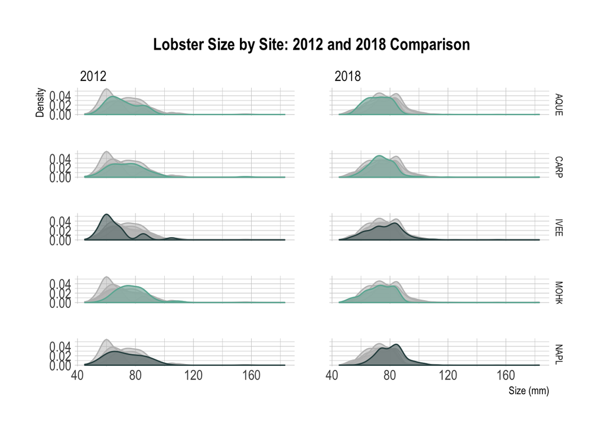

**Figure 3.** Graphs visualize California Spiny Lobster size distribution shifts from the start (2012) and the end (2018) of the data collection period examined in this mini-report. These shifts are examined for all SBC LTER study sites.

**B. Shifts in community size structure for all Santa Barbara Coastline sites in years 2012 and 2018:**

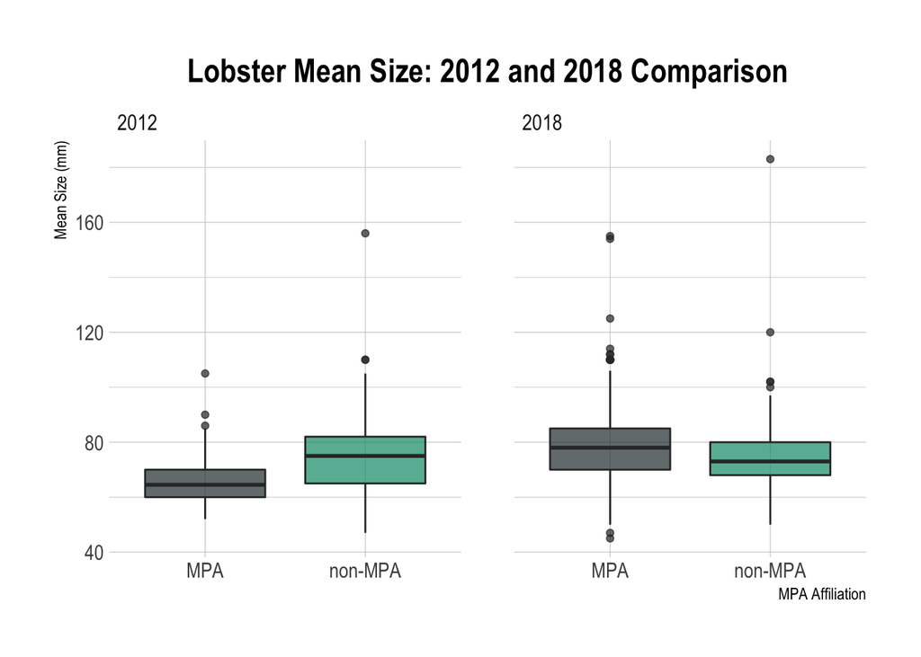

**Figure 4.** Graphs visualize mean size of California Spiny Lobsters in 2012 and 2018, comparing mean lobster size at MPA sites to mean lobster size at non-MPA sites for these specific years.

Figure 5. The table below includes the means, standard deviations, and sample sizes for MPA and non-MPA sites in 2012 and 2018.

| MPA Affiliation | Year | Mean Size | SD Size | Sample n |
| --- | --- | --- | --- | --- |
| MPA | 2012 | 67.37500 | 12.15425 | 32 |
| MPA | 2018 | 77.56672 | 11.70341 | 1244 |
| non-MPA | 2012 | 74.92462 | 12.41412 | 199 |
| non-MPA | 2018 | 73.61996 | 10.09438 | 561 |

**C. Mean lobster sizes at MPA verses non-MPA sites in 2012 and 2018:**

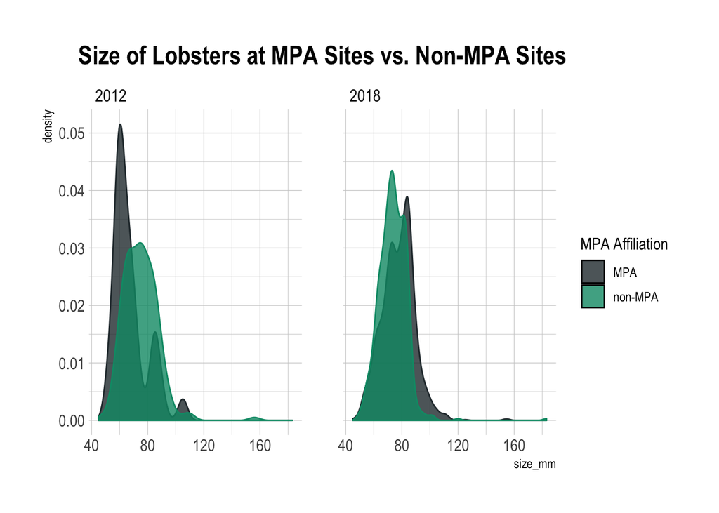

#### **Summary**

- All study sites displayed overall population stability between 2012 and 2018, with both MPA sites displaying an increase in abundance from 2017-2018 (Figure 2)
- Mean size of California Spiny Lobsters found in MPA sites increased between 2012 and 2018 (Figure 4)
- Mean size of California Spiny Lobsters found in non-MPA sites decreased between 2012 and 2018 (Figure 4)

#### **References**

[1] “California Spiny Lobster Fishery Management Plan.” [Online]. Available: https://www.wildlife.ca.gov/Conservation/Marine/Lobster-FMP. [Accessed: 16-Nov-2019].

[2] “Santa Barbara Coastal LTER.” [Online]. Available: https://sbclter.msi.ucsb.edu/. [Accessed: 16-Nov-2019].

[3] “The IUCN Red List of Threatened Species,” IUCN Red List of Threatened Species. [Online]. Available: https://www.iucnredlist.org/en. [Accessed: 16-Nov-2019].

[4]“Current 2019-2020 Recreational Lobster Fishing Information.” [Online]. Available: https://www.wildlife.ca.gov/Conservation/Marine/Invertebrates/Lobster. [Accessed: 17-Nov-2019].